# R Notebook

## Sampling Bowl Activity

from ModernDive [Chapter 7](https://moderndive.com/7-sampling.html). Read this chapter thoroughly and experiment with the simulation code. Simulations like this one are a linchpin for the work we do with data (i.e. taking real world situations and represent them with code).

Load the libraries required:

```r
library(tidyverse)
library(moderndive)
```

### Explore the Bowl dataset

```r
virt.shovel <- bowl
glimpse(virt.shovel)
```

```
Observations: 2,400
Variables: 2
$ ball_ID <int> 1, 2, 3, 4, 5, 6, 7, 8, 9, 10, 11, 12, 1...
$ color   <chr> "white", "white", "white", "red", "white...
```

### Count the Factors

Create a table showing red vs white and the breakout of the factors you will measure:

```r
tbl.colours <- table(virt.shovel$color)

colours <- virt.shovel %>%
  select(color) %>%
  mutate(tot.rows = n()) %>%
  filter(color == "red") %>%
  mutate(red.balls = n(), white.balls = tot.rows - red.balls) %>%
  mutate(pct.redballs = red.balls / tot.rows, pct.whiteballs = 1 - pct.redballs) %>%
  select(-color) %>%
  unique()

print(tbl.colours)
```

```
  red white
  900  1500
```

```r
print(colours)
```

| tot.rows | red.balls | white.balls | pct.redballs | pct.whiteballs |
| --- | --- | --- | --- | --- |
| 2400 | 900 | 1500 | 0.375 | 0.625 |

### Collect Samples

Glimpse at the sample, you can also click on the view icon under data pain or using the View() function.

```r
virt.shovel <- bowl %>%
  rep_sample_n(size = 50)
glimpse(virt.shovel)
```

```
Observations: 50
Variables: 3
Groups: replicate [1]
$ replicate <int> 1, 1, 1, 1, 1, 1, 1, 1, 1, 1, 1, 1, 1,...
$ ball_ID   <int> 755, 2196, 1447, 1639, 698, 559, 1566,...
$ color     <chr> "red", "red", "red", "white", "red", "...
```

### Create One Simulated Sample

Change the sample size above and see the variance on single shovel level. Compare results to the known populatin of 37.5% red balls.

```r
virt.shovel %>%
  mutate(is.red = (color == "red")) %>%
  summarise(num.red = sum(is.red), tot.sample = n()) %>%
  mutate(prop.red = (num.red / tot.sample))
```

| replicate | num.red | tot.sample | prop.red |
| --- | --- | --- | --- |
| 1 | 23 | 50 | 0.46 |

```r
NA
NA
```

### Create Multiple Samples

#### Explore the multiple samples.

We will use “reps” instead of a manual loop at the R Language level. *Reps* will perform more efficiently than a loop. Read the chapter to understand how the numbers for the replicate variable / column represent each “shovel” of the balls.

```r
virt.samples <- bowl %>%
  rep_sample_n(size = 50, reps = 33)

View(virt.samples)
```

### Summarize then Visualize

```r
virt.prop.red <- virt.samples %>%
  group_by(replicate) %>%
  summarise(red = sum(color == "red")) %>%
  mutate(prop.red = red / 50) # should create variable for total number of sample size

print(virt.prop.red)
```

| replicate | red | prop.red |
| --- | --- | --- |
| 1 | 17 | 0.34 |
| 2 | 23 | 0.46 |
| 3 | 15 | 0.30 |
| 4 | 23 | 0.46 |
| 5 | 23 | 0.46 |
| 6 | 17 | 0.34 |
| 7 | 17 | 0.34 |
| 8 | 26 | 0.52 |
| 9 | 14 | 0.28 |
| 10 | 22 | 0.44 |

[output cut: 23 more lines]

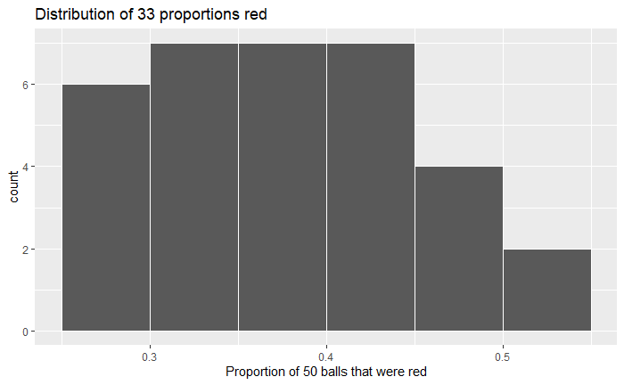

```r
ggplot(virt.prop.red, aes(x = prop.red)) +
  geom_histogram(binwidth = 0.05, boundary = 0.4, color = "white") +
  labs(x = "Proportion of 50 balls that were red",
       title = "Distribution of 33 proportions red")
```

### Differing Variables

Even though the exercise in the book is fairly “hard coded” compared to how you would want to create a simulation, use the code above to experiment with varying sample sizes as well different size “shovels” (i.e. 50 balls vs 100, etc) and compare. This section begins on 7.2.3 of the book. The better you have a handle on sampling the better statistics are understood.

Through experimentation observe the count sizes will increase but the histogram of the samples will resemble a normal distribution. The historgram will resemble this type of distribution more and more with each increase in sample sizes. This is what the Central Limit Theorem and the Law of Large Numbers is based on.